# Multimorbidity

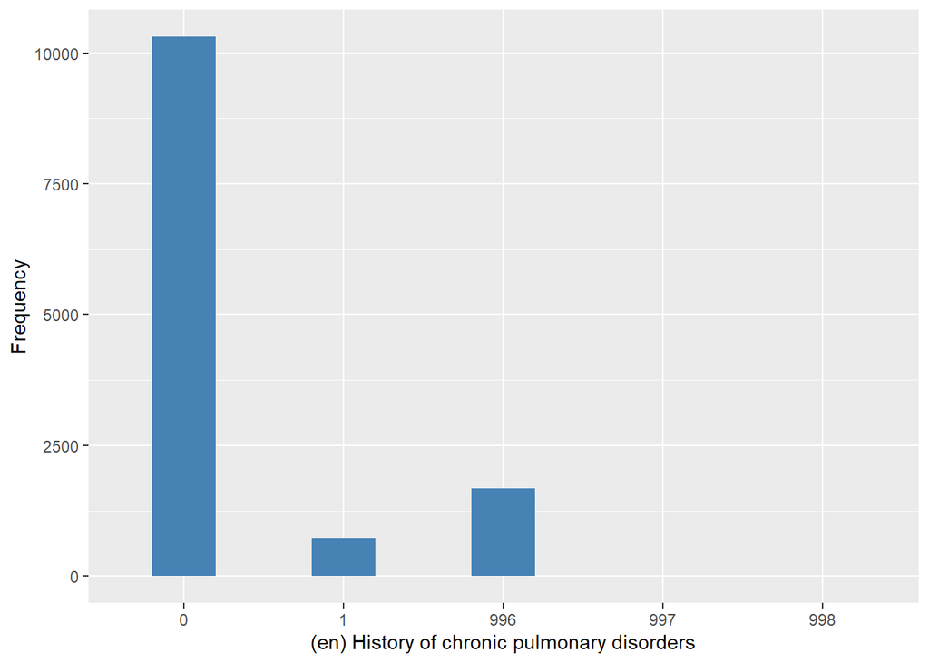

stroke

| Sample size | Missing values |
| --- | --- |
| 12731 | 1697 |

Category

|  | 0 | 1 |
| --- | --- | --- |
| Frequency | 10851.00 | 183.00 |
| Percentage | 85.23 | 1.44 |

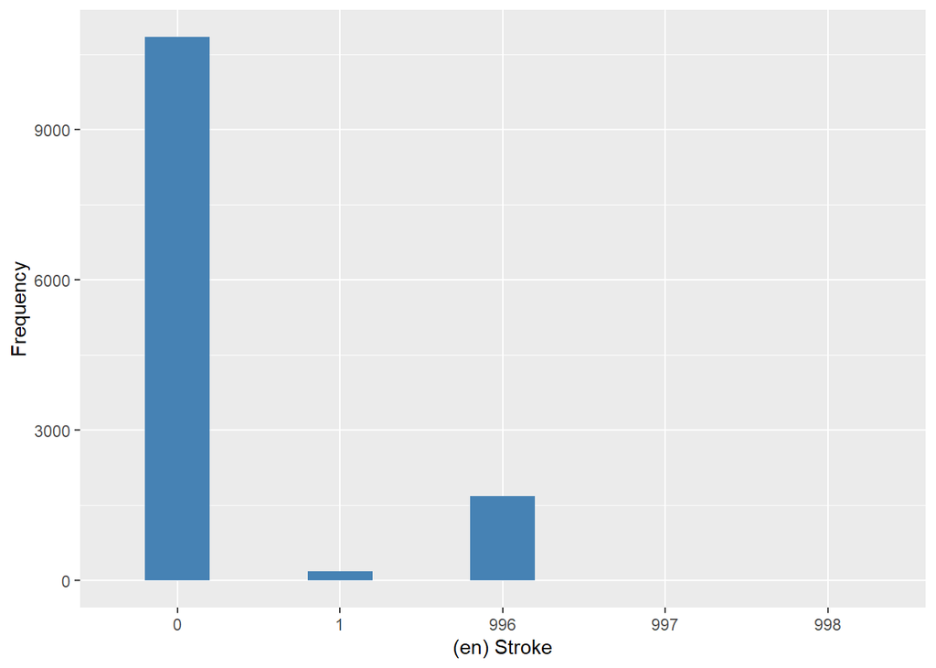

mi_ha

| Sample size | Missing values |
| --- | --- |
| 12731 | 1697 |

Category

|  | 0 | 1 |
| --- | --- | --- |
| Frequency | 10894.00 | 140.0 |
| Percentage | 85.57 | 1.1 |

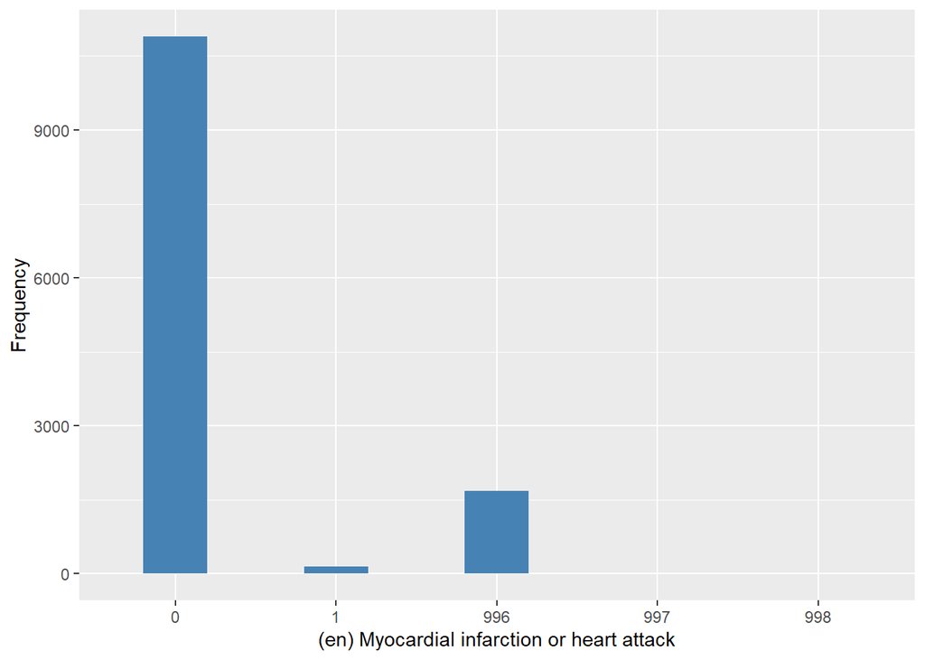

h_angina

| Sample size | Missing values |
| --- | --- |
| 12731 | 1697 |

Category

|  | 0 | 1 |
| --- | --- | --- |
| Frequency | 10101.00 | 933.00 |
| Percentage | 79.34 | 7.33 |

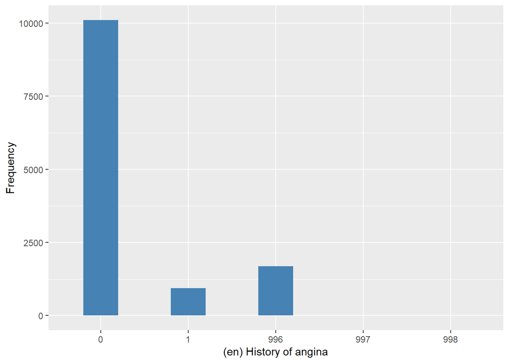

#### 2.1.4.2 Harmonisation algorithm

To compute `multimorbid` from the study-specific variables they have to be recoded as follows:

- `Multimorbid_score = sum(h_diabetes, h_asthma, h_hypertension, h_angina, mi_ha, h_joint_disorders, stroke, h_cpd)`
- `Multimorbid_status = 1 if multimorbid_score > = 2`
- `Multimorbid_status = 0 if multimorbid_score < 2`
- `otherwise into 999`

**R script:**

```r
ELSA_ds_w4 <- ELSA_w4 %>% mutate(dead = purrr::pmap(mutate_at(., vars(-id),
    `==`, 996) %>% select(., -id), all) %>% unlist()) %>% mutate_at(names(ELSA_w4[,
    -1]), ~replace(., list = which(. %in% 991:999), values = NA)) %>% mutate(multimorbid_score = rowSums(select(.,
    -1, -dead), na.rm = T)) %>% mutate(cardNA = rowSums(!is.na(select(., -1,
    -dead, -multimorbid_score)))) %>% mutate(cardNA = cardNA/cardNA) %>% mutate(multimorbid_score = multimorbid_score *
    cardNA) %>% mutate(multimorbid = case_when(multimorbid_score >= 2 ~ 1, multimorbid_score <
    2 ~ 0, dead ~ 996, TRUE ~ 999)) %>% select(id, multimorbid)
```

#### 2.1.4.3 Statistics of the new harmonized variable

Multimorbidity status

| Sample size | Missing values |
| --- | --- |
| 12731 | 1689 |

Category

|  | 0 | 1 |
| --- | --- | --- |
| Frequency | 7201.00 | 3841.00 |
| Percentage | 56.56 | 30.17 |

Type of missing

|  | 991 | 992 | 993 | 994 | 995 | 996 | 997 | 998 | 999 | NA |
| --- | --- | --- | --- | --- | --- | --- | --- | --- | --- | --- |
| Frequency | 0 | 0 | 0 | 0 | 0 | 1681.0 | 0 | 0 | 8.00 | 0 |
| Percentage | 0 | 0 | 0 | 0 | 0 | 13.2 | 0 | 0 | 0.06 | 0 |

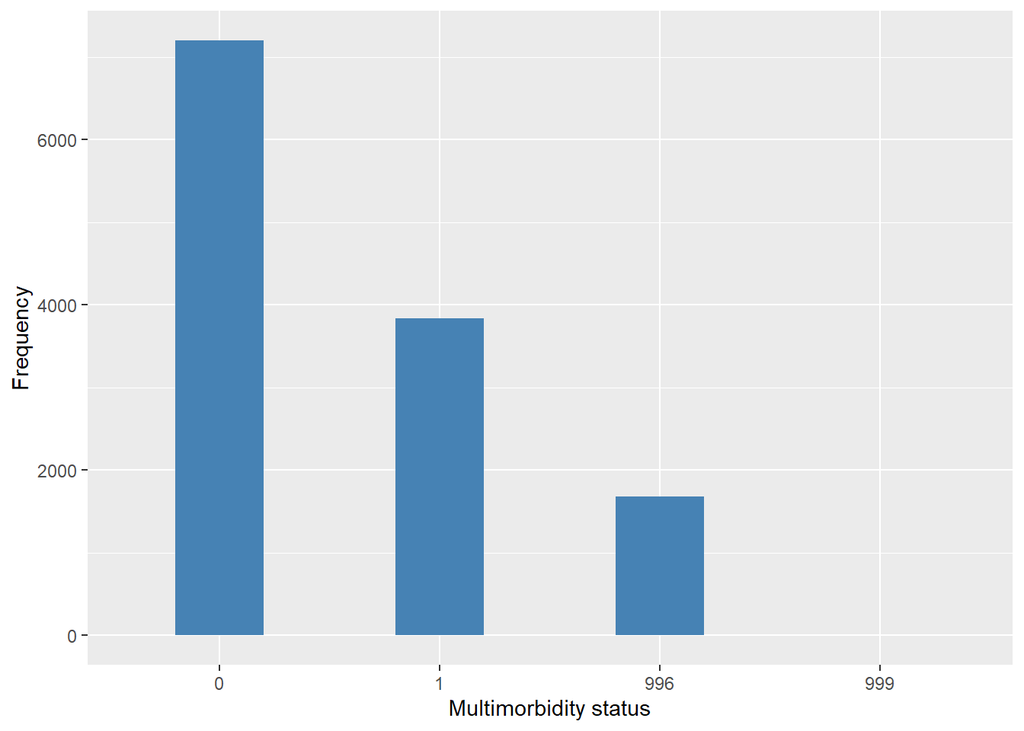

#### 2.1.4.4 Validation

### 2.1.5 Wave 5

#### 2.1.5.1 Study-specific variable description

| **Name** | `h_diabetes` | `h_asthma` | `h_hypertension` | `h_joint_disorders` | `h_cpd` | `stroke` | `mi_ha` | `h_angina` |
| --- | --- | --- | --- | --- | --- | --- | --- | --- |
| **Label** | `History of diabetes mellitus` | `History of asthma` | `History of hypertension` | `History of arthritis, rheumatism or osteoarthritis` | `History of chronic pulmonary disorders` | `Stroke` | `Myocardial infarction or heart attack` | `History of angina` |
| **Table name** | `elsa_w5_hd` | `elsa_w5_hd` | `elsa_w5_hd` | `elsa_w5_hd` | `elsa_w5_hd` | `elsa_w5_hd` | `elsa_w5_hd` | `elsa_w5_hd` |
| **Categories** | `0 = No` `1 = Yes` | `0 = No` `1 = Yes` | `0 = No` `1 = Yes` | `0 = No` `1 = Yes` | `0 = No` `1 = Yes` | `0 = No` `1 = Yes` | `0 = No` `1 = Yes` | `0 = No` `1 = Yes` |
| **Missings** | `996 = Not applicable` `997 = Refuse` `998 = Do not know` `999 = Missing` | `996 = Not applicable` `997 = Refuse` `998 = Do not know` `999 = Missing` | `996 = Not applicable` `997 = Refuse` `998 = Do not know` `999 = Missing` | `996 = Not applicable` `997 = Refuse` `998 = Do not know` `999 = Missing` | `996 = Not applicable` `997 = Refuse` `998 = Do not know` `999 = Missing` | `996 = Not applicable` `997 = Refuse` `998 = Do not know` `999 = Missing` | `996 = Not applicable` `997 = Refuse` `998 = Do not know` `999 = Missing` | `996 = Not applicable` `997 = Refuse` `998 = Do not know` `999 = Missing` |
| **Description** |  |  |  |  |  |  |  |  |

h_diabetes

| Sample size | Missing values |
| --- | --- |
| 12569 | 2309 |

Category

|  | 0 | 1 |
| --- | --- | --- |
| Frequency | 9057.00 | 1203.00 |
| Percentage | 72.06 | 9.57 |

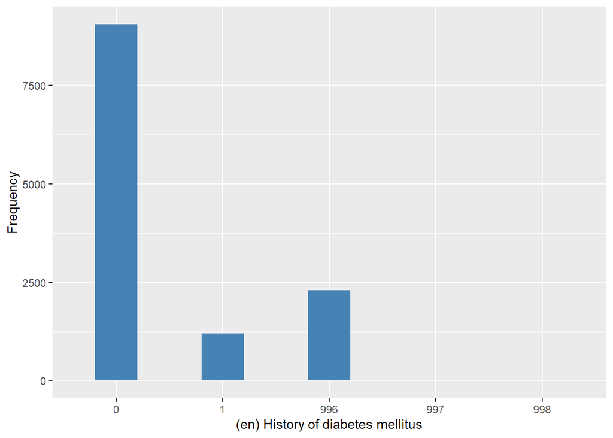

h_asthma

| Sample size | Missing values |
| --- | --- |
| 12569 | 2310 |

Category

|  | 0 | 1 |
| --- | --- | --- |
| Frequency | 8801.00 | 1458.0 |
| Percentage | 70.02 | 11.6 |

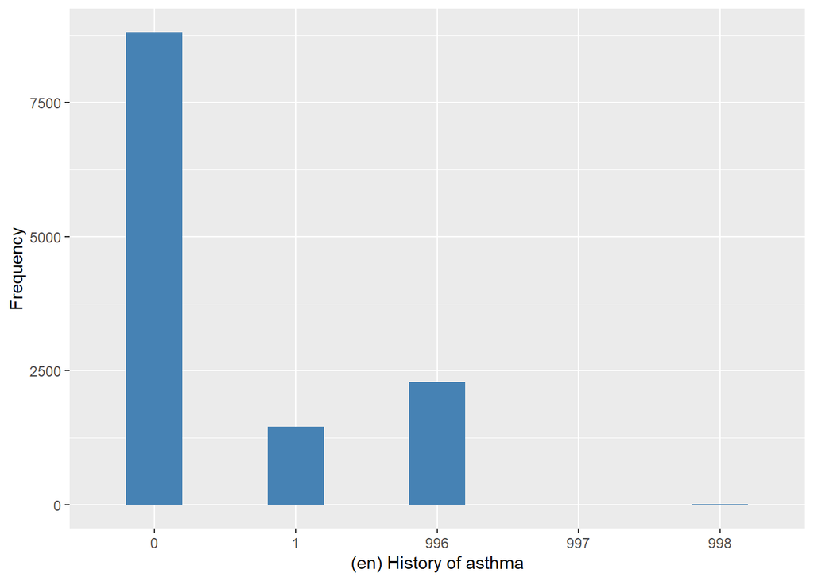

h_hypertension

| Sample size | Missing values |
| --- | --- |
| 12569 | 2305 |

Category

|  | 0 | 1 |
| --- | --- | --- |
| Frequency | 5544.00 | 4720.00 |
| Percentage | 44.11 | 37.55 |

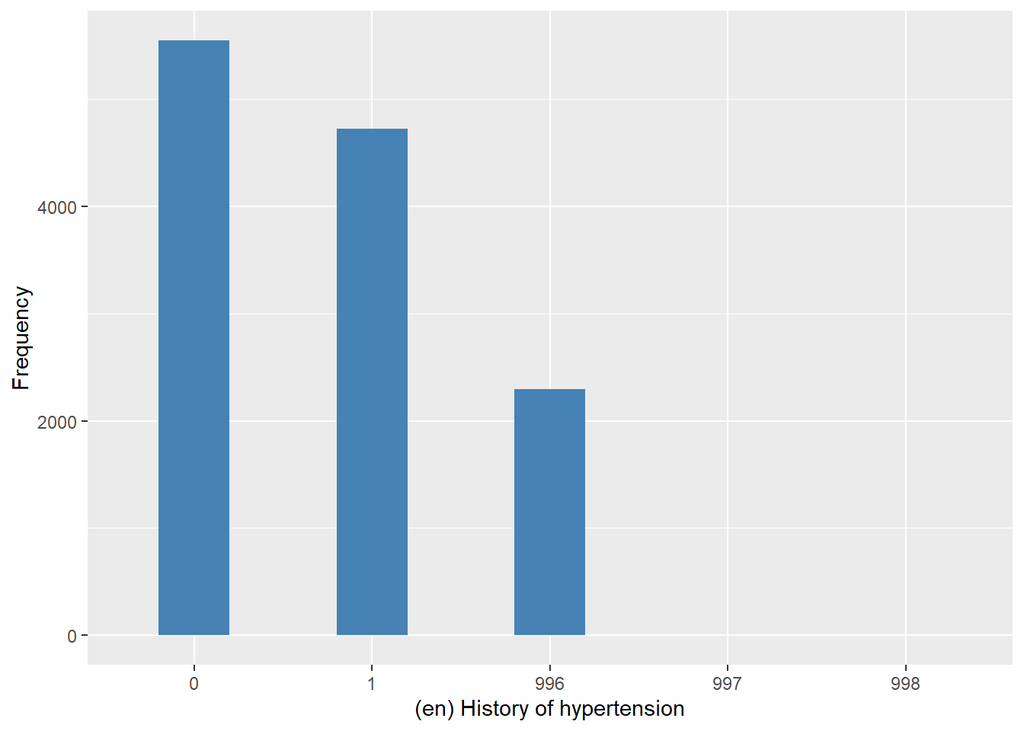

h_joint_disorders

| Sample size | Missing values |
| --- | --- |
| 12569 | 2305 |

Category

|  | 0 | 1 |
| --- | --- | --- |
| Frequency | 6095.00 | 4169.00 |
| Percentage | 48.49 | 33.17 |

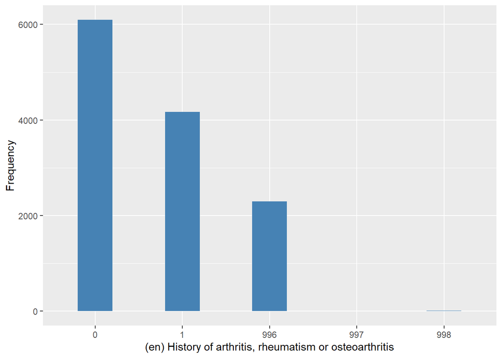

h_cpd

| Sample size | Missing values |
| --- | --- |
| 12569 | 2309 |

Category

|  | 0 | 1 |
| --- | --- | --- |
| Frequency | 9516.00 | 744.00 |
| Percentage | 75.71 | 5.92 |

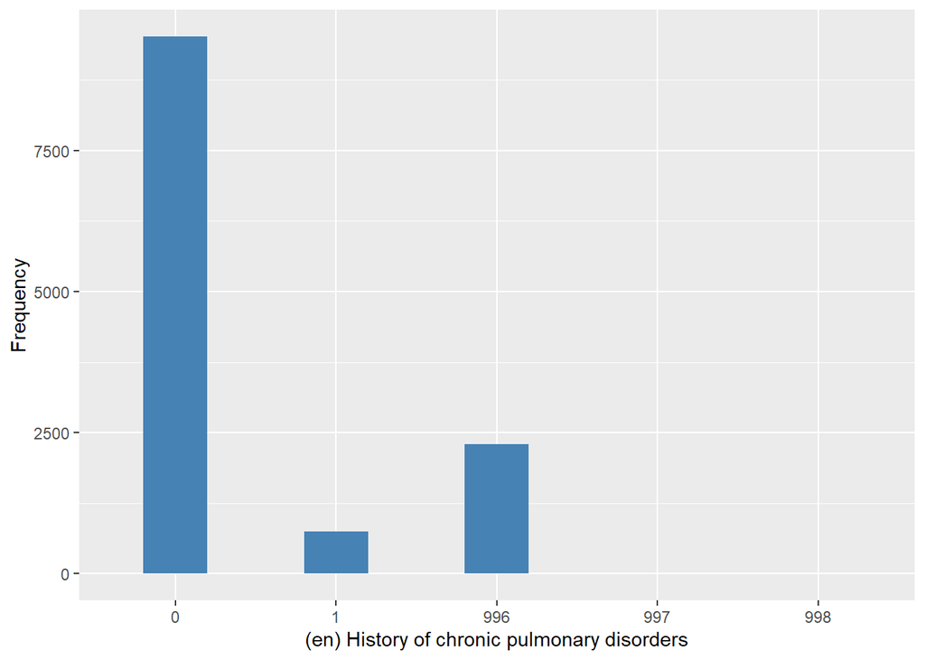

stroke

| Sample size | Missing values |
| --- | --- |
| 12569 | 2310 |

Category

|  | 0 | 1 |
| --- | --- | --- |
| Frequency | 10110.00 | 149.00 |
| Percentage | 80.44 | 1.19 |

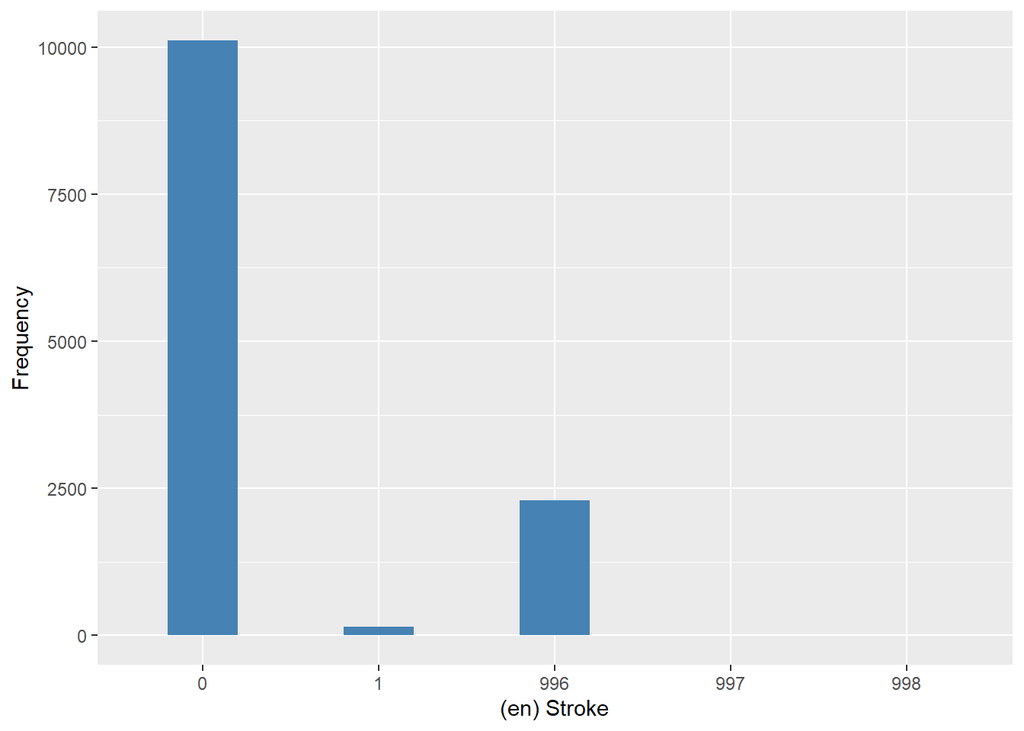

mi_ha

| Sample size | Missing values |
| --- | --- |
| 12569 | 2310 |

Category

|  | 0 | 1 |
| --- | --- | --- |
| Frequency | 10137.00 | 122.00 |
| Percentage | 80.65 | 0.97 |

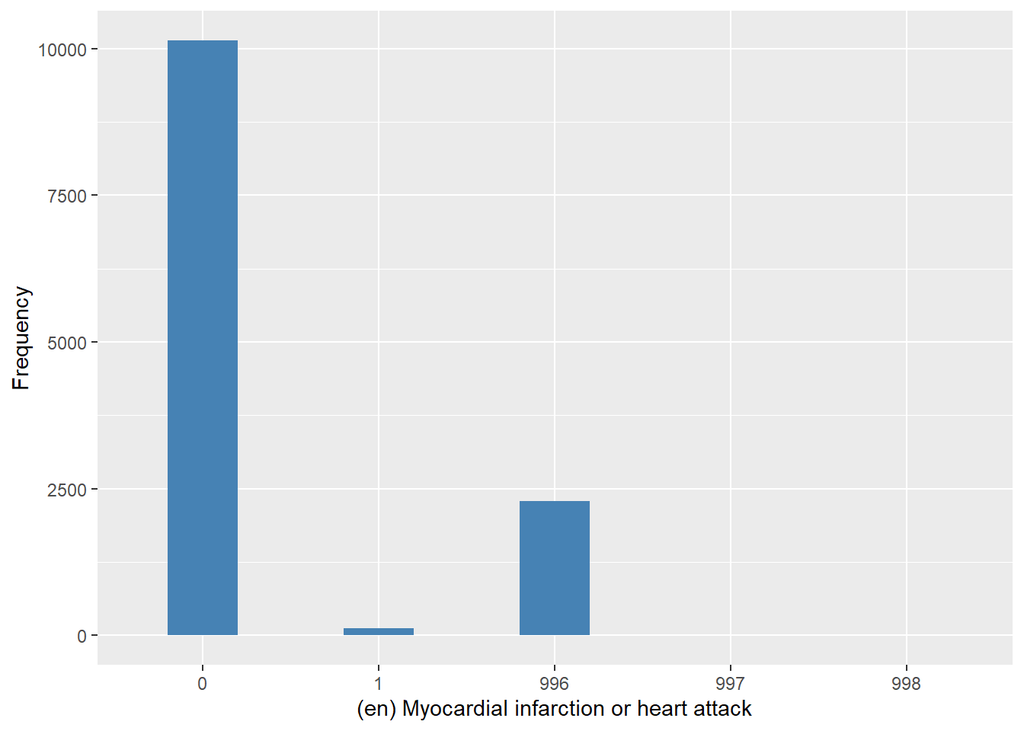

h_angina

| Sample size | Missing values |
| --- | --- |
| 12569 | 2308 |

Category

|  | 0 | 1 |
| --- | --- | --- |
| Frequency | 9359.00 | 902.00 |
| Percentage | 74.46 | 7.18 |

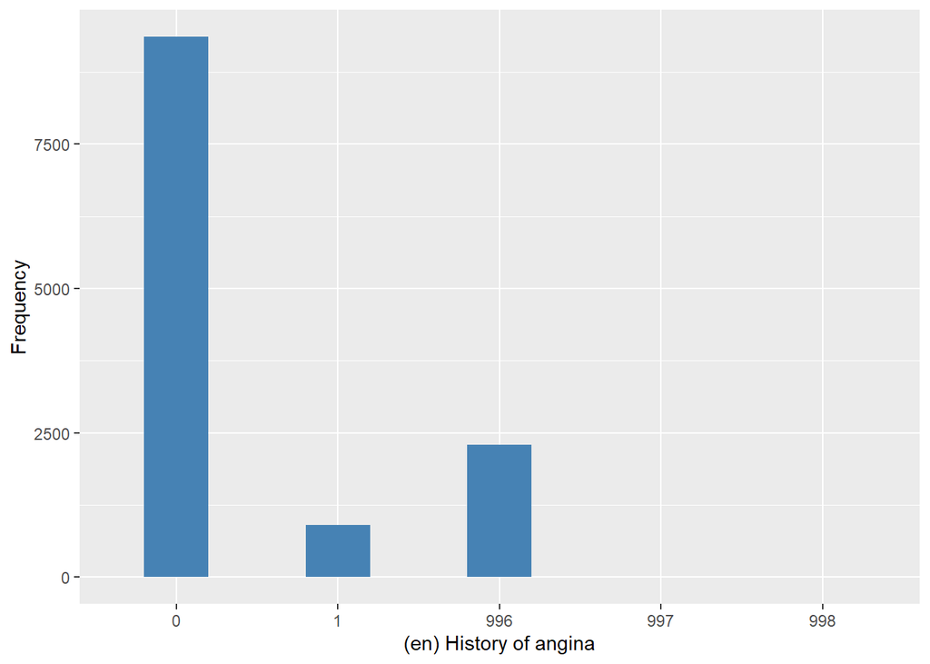

#### 2.1.5.2 Harmonisation algorithm

To compute `multimorbid` from the study-specific variables they have to be recoded as follows:

- `Multimorbid_score = sum(h_diabetes, h_asthma, h_hypertension, h_angina, mi_ha, h_joint_disorders, stroke, h_cpd)`
- `Multimorbid_status = 1 if multimorbid_score > = 2`
- `Multimorbid_status = 0 if multimorbid_score < 2`
- `otherwise into 999`

**R script:**

```r
ELSA_ds_w5 <- ELSA_w5 %>% mutate(dead = purrr::pmap(mutate_at(., vars(-id),
    `==`, 996) %>% select(., -id), all) %>% unlist()) %>% mutate_at(names(ELSA_w5[,
    -1]), ~replace(., list = which(. %in% 991:999), values = NA)) %>% mutate(multimorbid_score = rowSums(select(.,
    -1, -dead), na.rm = T)) %>% mutate(cardNA = rowSums(!is.na(select(., -1,
    -dead, -multimorbid_score)))) %>% mutate(cardNA = cardNA/cardNA) %>% mutate(multimorbid_score = multimorbid_score *
    cardNA) %>% mutate(multimorbid = case_when(multimorbid_score >= 2 ~ 1, multimorbid_score <
    2 ~ 0, dead ~ 996, TRUE ~ 999)) %>% select(id, multimorbid)
```

#### 2.1.5.3 Statistics of the new harmonized variable

Multimorbidity status

| Sample size | Missing values |
| --- | --- |
| 12569 | 2301 |

Category

|  | 0 | 1 |
| --- | --- | --- |
| Frequency | 6318.00 | 3950.00 |
| Percentage | 50.27 | 31.43 |

Type of missing

|  | 991 | 992 | 993 | 994 | 995 | 996 | 997 | 998 | 999 | NA |
| --- | --- | --- | --- | --- | --- | --- | --- | --- | --- | --- |
| Frequency | 0 | 0 | 0 | 0 | 0 | 2295.00 | 0 | 0 | 6.00 | 0 |
| Percentage | 0 | 0 | 0 | 0 | 0 | 18.26 | 0 | 0 | 0.05 | 0 |

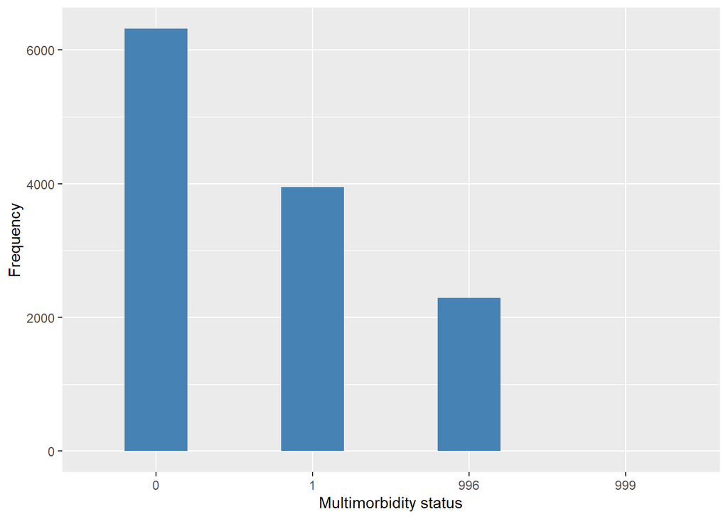

#### 2.1.5.4 Validation

### 2.1.6 Wave 6

#### 2.1.6.1 Study-specific variable description

| **Name** | `h_diabetes` | `h_asthma` | `h_hypertension` | `h_joint_disorders` | `h_cpd` | `stroke` | `mi_ha` | `h_angina` |
| --- | --- | --- | --- | --- | --- | --- | --- | --- |
| **Label** | `History of diabetes mellitus` | `History of asthma` | `History of hypertension` | `History of arthritis, rheumatism or osteoarthritis` | `History of chronic pulmonary disorders` | `Stroke` | `Myocardial infarction or heart attack` | `History of angina` |
| **Table name** | `elsa_w6_hd` | `elsa_w6_hd` | `elsa_w6_hd` | `elsa_w6_hd` | `elsa_w6_hd` | `elsa_w6_hd` | `elsa_w6_hd` | `elsa_w6_hd` |
| **Categories** | `0 = No` `1 = Yes` | `0 = No` `1 = Yes` | `0 = No` `1 = Yes` | `0 = No` `1 = Yes` | `0 = No` `1 = Yes` | `0 = No` `1 = Yes` | `0 = No` `1 = Yes` | `0 = No` `1 = Yes` |
| **Missings** | `996 = Not applicable` `997 = Refuse` `998 = Do not know` `999 = Missing` | `996 = Not applicable` `997 = Refuse` `998 = Do not know` `999 = Missing` | `996 = Not applicable` `997 = Refuse` `998 = Do not know` `999 = Missing` | `996 = Not applicable` `997 = Refuse` `998 = Do not know` `999 = Missing` | `996 = Not applicable` `997 = Refuse` `998 = Do not know` `999 = Missing` | `996 = Not applicable` `997 = Refuse` `998 = Do not know` `999 = Missing` | `996 = Not applicable` `997 = Refuse` `998 = Do not know` `999 = Missing` | `996 = Not applicable` `997 = Refuse` `998 = Do not know` `999 = Missing` |
| **Description** |  |  |  |  |  |  |  |  |

h_diabetes

| Sample size | Missing values |
| --- | --- |
| 13359 | 2769 |

Category

|  | 0 | 1 |
| --- | --- | --- |
| Frequency | 9305.00 | 1285.00 |
| Percentage | 69.65 | 9.62 |

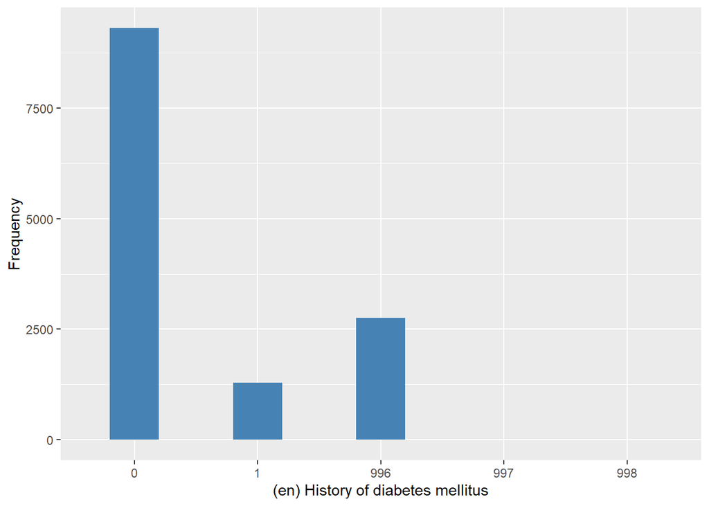

h_asthma

| Sample size | Missing values |
| --- | --- |
| 13359 | 2766 |

Category

|  | 0 | 1 |
| --- | --- | --- |
| Frequency | 9078.00 | 1515.00 |
| Percentage | 67.95 | 11.34 |

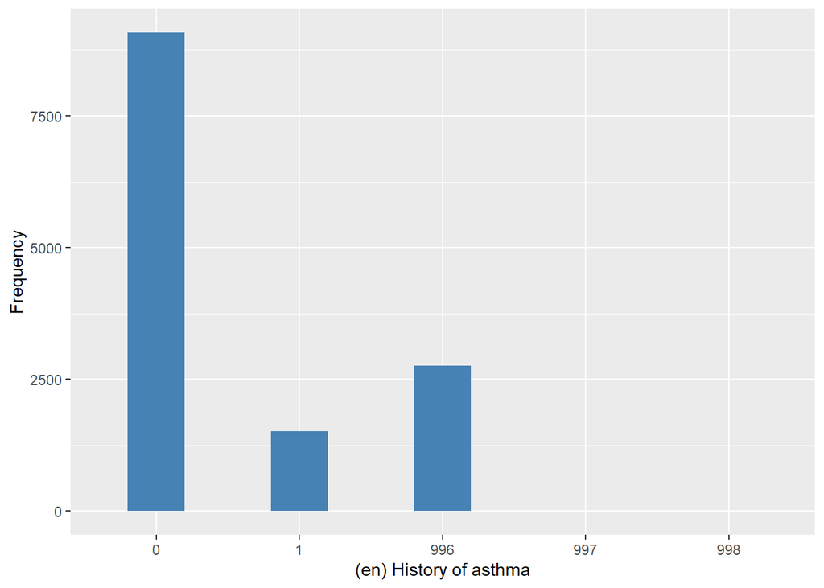

h_hypertension

| Sample size | Missing values |
| --- | --- |
| 13359 | 2766 |

Category

|  | 0 | 1 |
| --- | --- | --- |
| Frequency | 5802.00 | 4791.00 |
| Percentage | 43.43 | 35.86 |

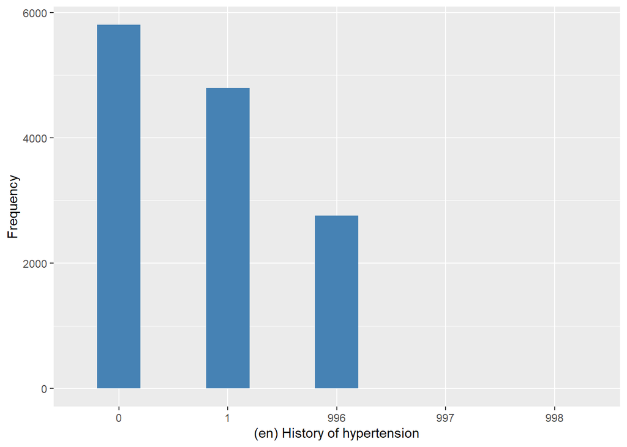

h_joint_disorders

| Sample size | Missing values |
| --- | --- |
| 13359 | 2764 |

Category

|  | 0 | 1 |
| --- | --- | --- |
| Frequency | 6280.00 | 4315.0 |
| Percentage | 47.01 | 32.3 |

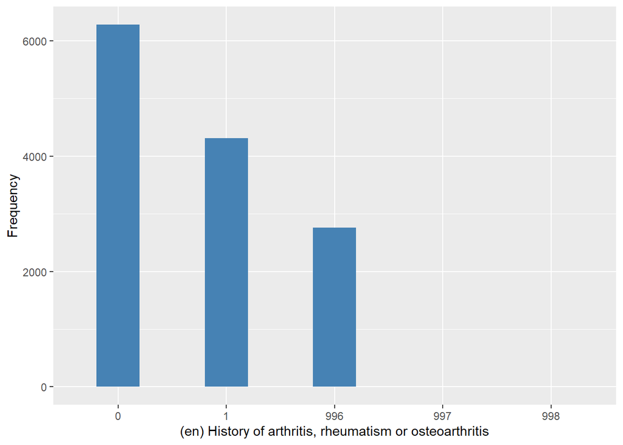

h_cpd

| Sample size | Missing values |
| --- | --- |
| 13359 | 2766 |

Category

|  | 0 | 1 |
| --- | --- | --- |
| Frequency | 9813.00 | 780.00 |
| Percentage | 73.46 | 5.84 |

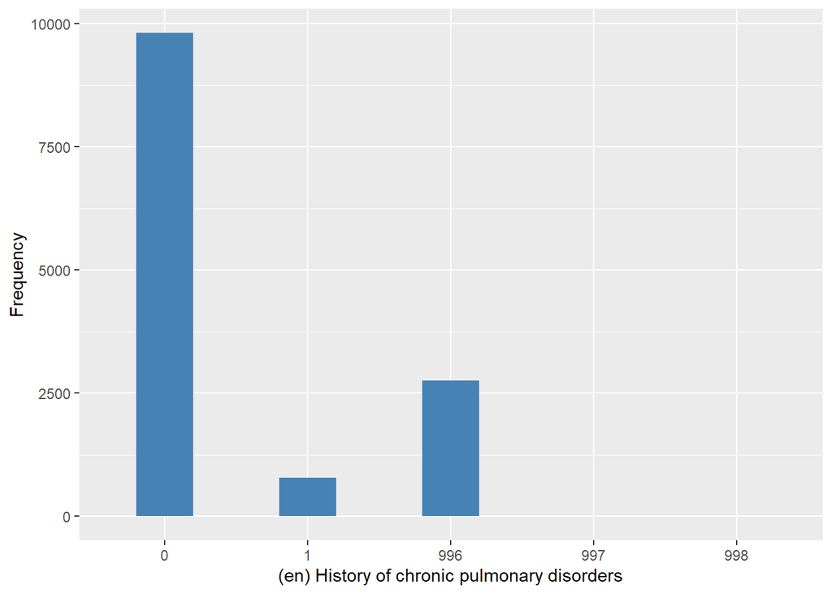

stroke

| Sample size | Missing values |
| --- | --- |
| 13359 | 2769 |

Category

|  | 0 | 1 |
| --- | --- | --- |
| Frequency | 10432.00 | 158.00 |
| Percentage | 78.09 | 1.18 |

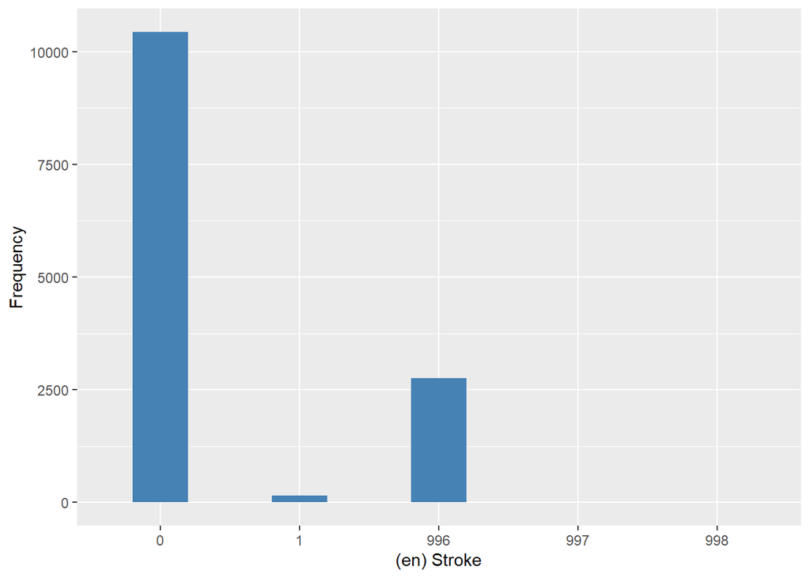

mi_ha

| Sample size | Missing values |
| --- | --- |
| 13359 | 2769 |

Category

|  | 0 | 1 |
| --- | --- | --- |
| Frequency | 10462.00 | 128.00 |
| Percentage | 78.31 | 0.96 |

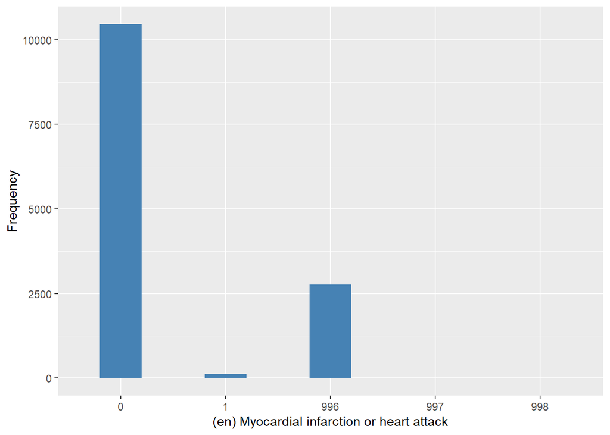

h_angina

| Sample size | Missing values |
| --- | --- |
| 13359 | 2768 |

Category

|  | 0 | 1 |
| --- | --- | --- |
| Frequency | 9745.00 | 846.00 |
| Percentage | 72.95 | 6.33 |

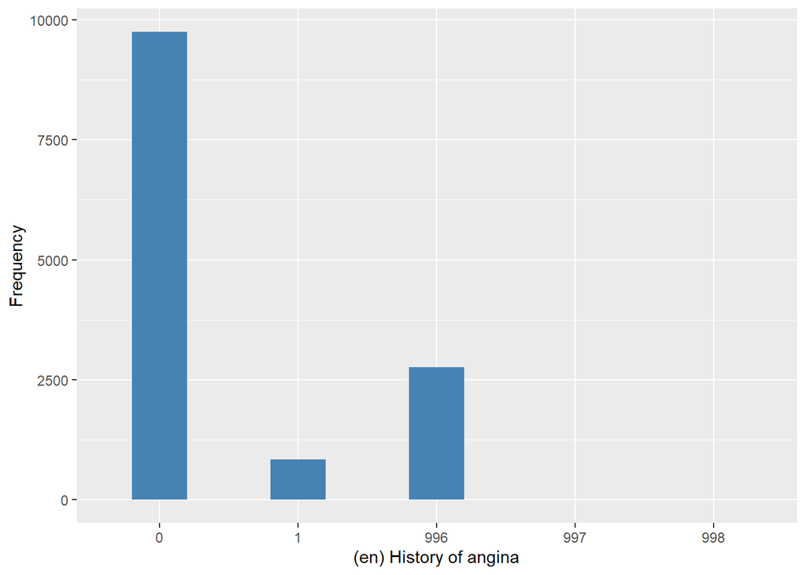

#### 2.1.6.2 Harmonisation algorithm

To compute `multimorbid` from the study-specific variables they have to be recoded as follows:

- `Multimorbid_score = sum(h_diabetes, h_asthma, h_hypertension, h_angina, mi_ha, h_joint_disorders, stroke, h_cpd)`
- `Multimorbid_status = 1 if multimorbid_score > = 2`
- `Multimorbid_status = 0 if multimorbid_score < 2`
- `otherwise into 999`

**R script:**

```r
ELSA_ds_w6 <- ELSA_w6 %>% mutate(dead = purrr::pmap(mutate_at(., vars(-id),
    `==`, 996) %>% select(., -id), all) %>% unlist()) %>% mutate_at(names(ELSA_w6[,
    -1]), ~replace(., list = which(. %in% 991:999), values = NA)) %>% mutate(multimorbid_score = rowSums(select(.,
    -1, -dead), na.rm = T)) %>% mutate(cardNA = rowSums(!is.na(select(., -1,
    -dead, -multimorbid_score)))) %>% mutate(cardNA = cardNA/cardNA) %>% mutate(multimorbid_score = multimorbid_score *
    cardNA) %>% mutate(multimorbid = case_when(multimorbid_score >= 2 ~ 1, multimorbid_score <
    2 ~ 0, dead ~ 996, TRUE ~ 999)) %>% select(id, multimorbid)
```

#### 2.1.6.3 Statistics of the new harmonized variable

Multimorbidity status

| Sample size | Missing values |
| --- | --- |
| 13359 | 2763 |

Category

|  | 0 | 1 |
| --- | --- | --- |
| Frequency | 6563.00 | 4033.00 |
| Percentage | 49.13 | 30.19 |

Type of missing

|  | 991 | 992 | 993 | 994 | 995 | 996 | 997 | 998 | 999 | NA |
| --- | --- | --- | --- | --- | --- | --- | --- | --- | --- | --- |
| Frequency | 0 | 0 | 0 | 0 | 0 | 2758.00 | 0 | 0 | 5.00 | 0 |
| Percentage | 0 | 0 | 0 | 0 | 0 | 20.65 | 0 | 0 | 0.04 | 0 |

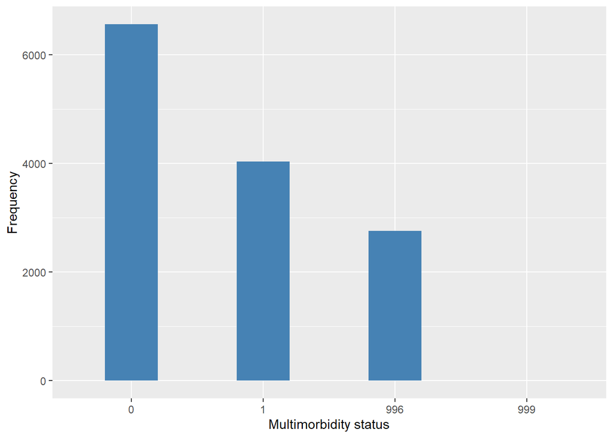

#### 2.1.6.4 Validation

### 2.1.7 Wave 7

#### 2.1.7.1 Study-specific variable description

| **Name** | `h_diabetes` | `h_asthma` | `h_hypertension` | `h_joint_disorders` | `h_cpd` | `stroke` | `mi_ha` | `h_angina` |
| --- | --- | --- | --- | --- | --- | --- | --- | --- |
| **Label** | `History of diabetes mellitus` | `History of asthma` | `History of hypertension` | `History of arthritis, rheumatism or osteoarthritis` | `History of chronic pulmonary disorders` | `Stroke` | `Myocardial infarction or heart attack` | `History of angina` |
| **Table name** | `elsa_w7_hd` | `elsa_w7_hd` | `elsa_w7_hd` | `elsa_w7_hd` | `elsa_w7_hd` | `elsa_w7_hd` | `elsa_w7_hd` | `elsa_w7_hd` |
| **Categories** | `0 = No` `1 = Yes` | `0 = No` `1 = Yes` | `0 = No` `1 = Yes` | `0 = No` `1 = Yes` | `0 = No` `1 = Yes` | `0 = No` `1 = Yes` | `0 = No` `1 = Yes` | `0 = No` `1 = Yes` |
| **Missings** | `996 = Not applicable` `997 = Refuse` `998 = Do not know` `999 = Missing` | `996 = Not applicable` `997 = Refuse` `998 = Do not know` `999 = Missing` | `996 = Not applicable` `997 = Refuse` `998 = Do not know` `999 = Missing` | `996 = Not applicable` `997 = Refuse` `998 = Do not know` `999 = Missing` | `996 = Not applicable` `997 = Refuse` `998 = Do not know` `999 = Missing` | `996 = Not applicable` `997 = Refuse` `998 = Do not know` `999 = Missing` | `996 = Not applicable` `997 = Refuse` `998 = Do not know` `999 = Missing` | `996 = Not applicable` `997 = Refuse` `998 = Do not know` `999 = Missing` |
| **Description** |  |  |  |  |  |  |  |  |

h_diabetes

| Sample size | Missing values |
| --- | --- |
| 12427 | 2767 |

Category

|  | 0 | 1 |
| --- | --- | --- |
| Frequency | 8399.00 | 1261.00 |
| Percentage | 67.59 | 10.15 |

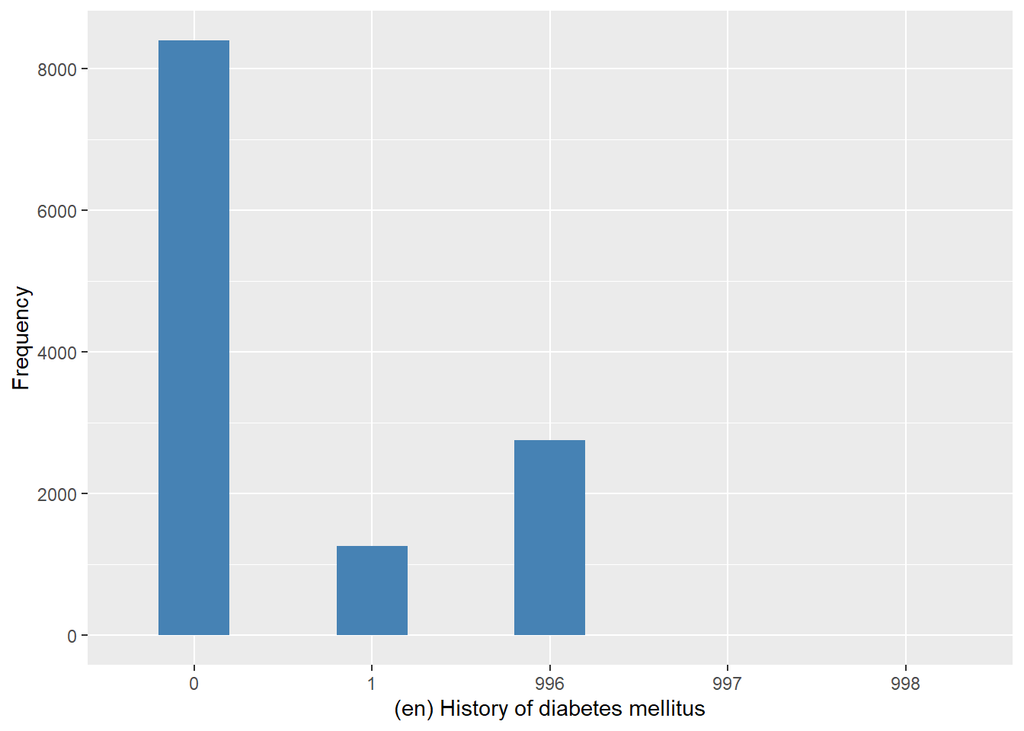

h_asthma

| Sample size | Missing values |
| --- | --- |
| 12427 | 2764 |

Category

|  | 0 | 1 |
| --- | --- | --- |
| Frequency | 8233.00 | 1430.00 |
| Percentage | 66.25 | 11.51 |

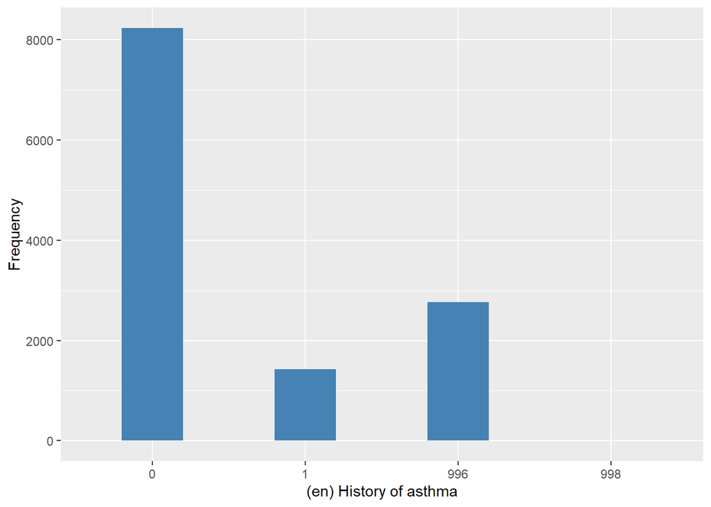

h_hypertension

| Sample size | Missing values |
| --- | --- |
| 12427 | 2764 |

Category

|  | 0 | 1 |
| --- | --- | --- |
| Frequency | 5224.00 | 4439.00 |
| Percentage | 42.04 | 35.72 |

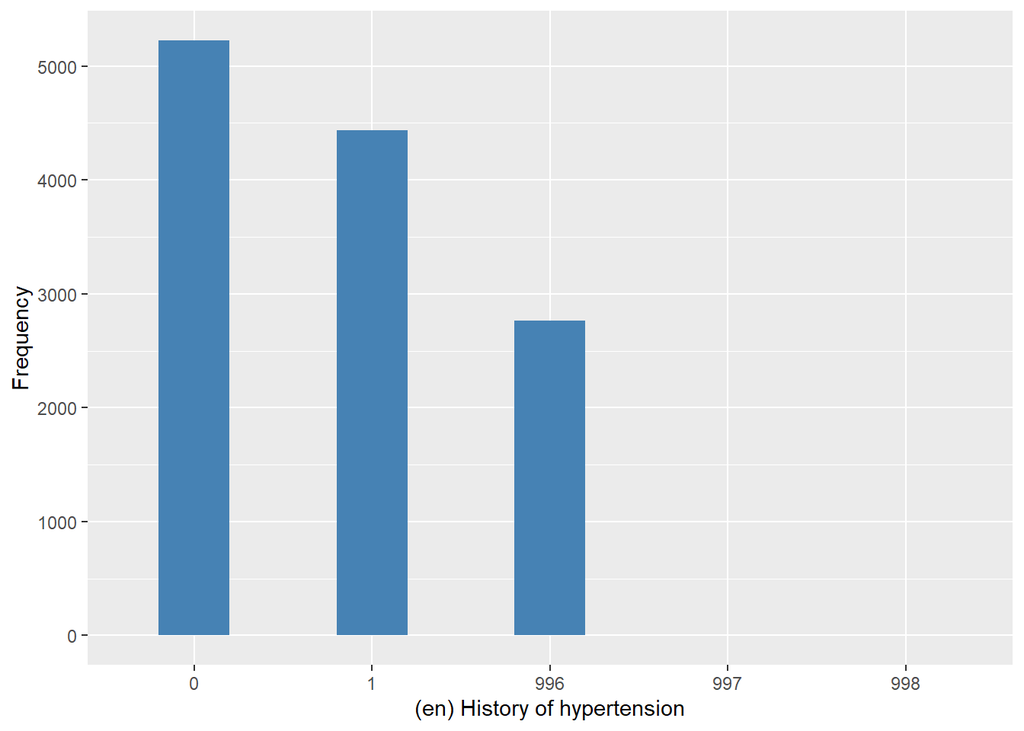

h_joint_disorders

| Sample size | Missing values |
| --- | --- |
| 12427 | 2763 |

Category

|  | 0 | 1 |
| --- | --- | --- |
| Frequency | 5635.00 | 4029.00 |
| Percentage | 45.34 | 32.42 |

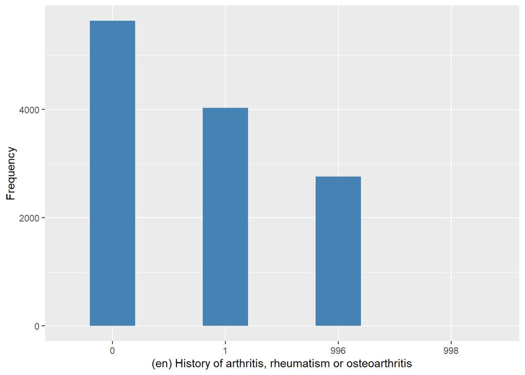

h_cpd

| Sample size | Missing values |
| --- | --- |
| 12427 | 2765 |

Category

|  | 0 | 1 |
| --- | --- | --- |
| Frequency | 8919.00 | 743.00 |
| Percentage | 71.77 | 5.98 |

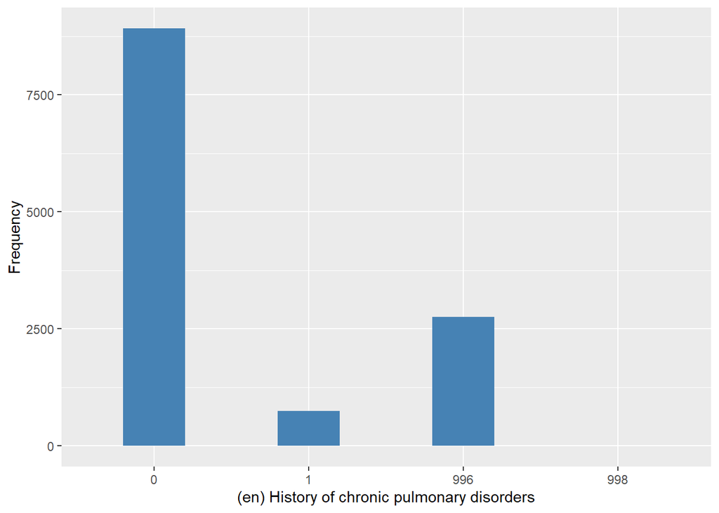

stroke

| Sample size | Missing values |
| --- | --- |
| 12427 | 2767 |

Category

|  | 0 | 1 |
| --- | --- | --- |
| Frequency | 9522.00 | 138.00 |
| Percentage | 76.62 | 1.11 |

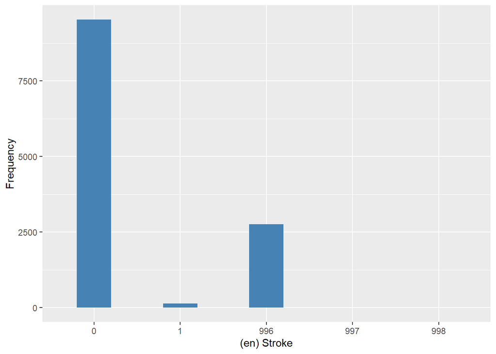

mi_ha

| Sample size | Missing values |
| --- | --- |
| 12427 | 2767 |

Category

|  | 0 | 1 |
| --- | --- | --- |
| Frequency | 9554.00 | 106.00 |
| Percentage | 76.88 | 0.85 |

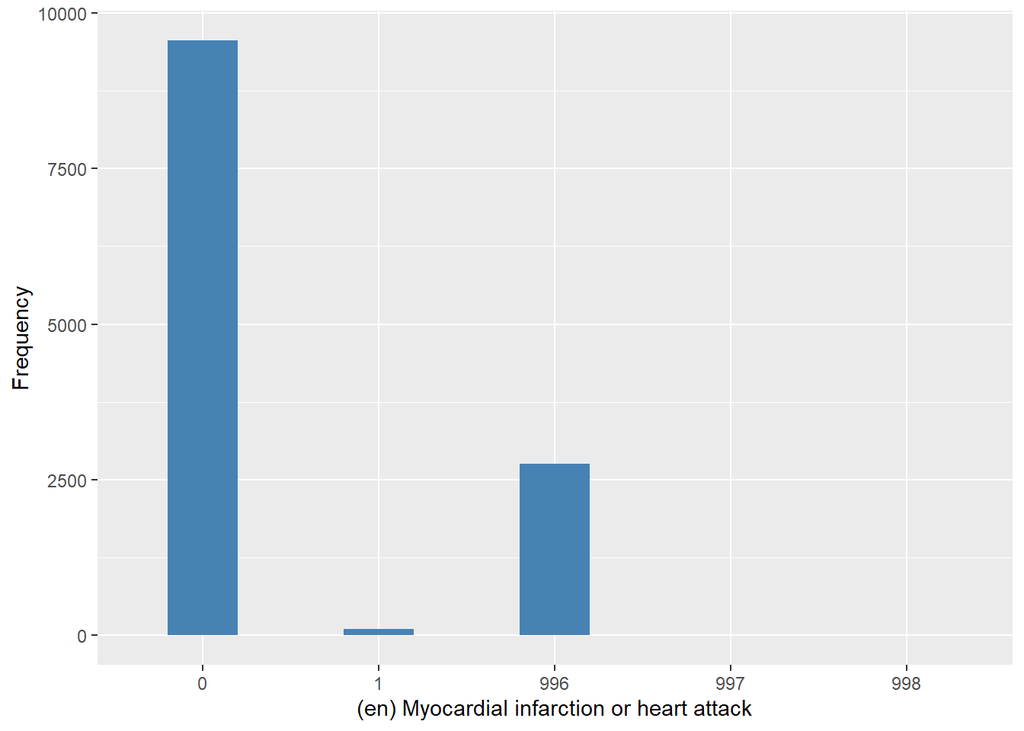

h_angina

| Sample size | Missing values |
| --- | --- |
| 12427 | 2767 |

Category

|  | 0 | 1 |
| --- | --- | --- |
| Frequency | 8908.00 | 752.00 |
| Percentage | 71.68 | 6.05 |

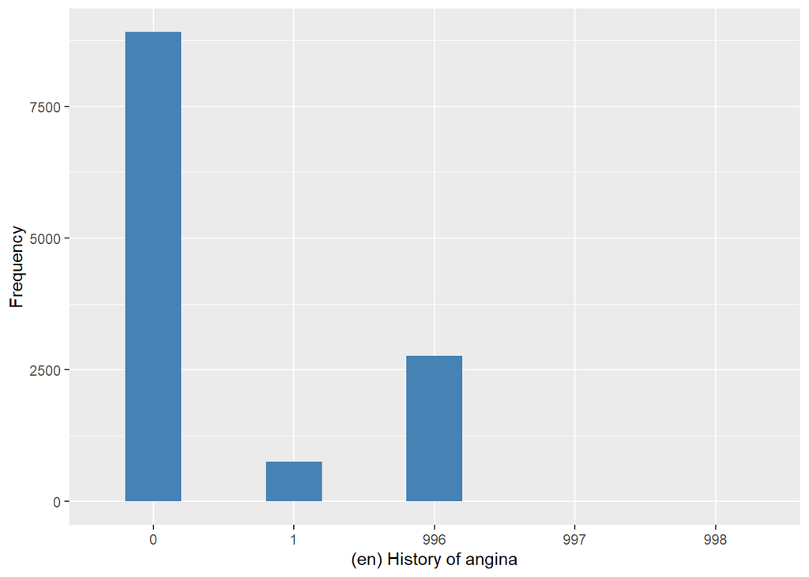

#### 2.1.7.2 Harmonisation algorithm

To compute `multimorbid` from the study-specific variables they have to be recoded as follows:

- `Multimorbid_score = sum(h_diabetes, h_asthma, h_hypertension, h_angina, mi_ha, h_joint_disorders, stroke, h_cpd)`
- `Multimorbid_status = 1 if multimorbid_score > = 2`
- `Multimorbid_status = 0 if multimorbid_score < 2`
- `otherwise into 999`

**R script:**

```r
ELSA_ds_w7 <- ELSA_w7 %>% mutate(dead = purrr::pmap(mutate_at(., vars(-id),
    `==`, 996) %>% select(., -id), all) %>% unlist()) %>% mutate_at(names(ELSA_w7[,
    -1]), ~replace(., list = which(. %in% 991:999), values = NA)) %>% mutate(multimorbid_score = rowSums(select(.,
    -1, -dead), na.rm = T)) %>% mutate(cardNA = rowSums(!is.na(select(., -1,
    -dead, -multimorbid_score)))) %>% mutate(cardNA = cardNA/cardNA) %>% mutate(multimorbid_score = multimorbid_score *
    cardNA) %>% mutate(multimorbid = case_when(multimorbid_score >= 2 ~ 1, multimorbid_score <
    2 ~ 0, dead ~ 996, TRUE ~ 999)) %>% select(id, multimorbid)
```

#### 2.1.7.3 Statistics of the new harmonized variable

Multimorbidity status

| Sample size | Missing values |
| --- | --- |
| 12427 | 2761 |

Category

|  | 0 | 1 |
| --- | --- | --- |
| Frequency | 5870.00 | 3796.00 |
| Percentage | 47.24 | 30.55 |

Type of missing

|  | 991 | 992 | 993 | 994 | 995 | 996 | 997 | 998 | 999 | NA |
| --- | --- | --- | --- | --- | --- | --- | --- | --- | --- | --- |
| Frequency | 0 | 0 | 0 | 0 | 0 | 2761.00 | 0 | 0 | 0 | 0 |
| Percentage | 0 | 0 | 0 | 0 | 0 | 22.22 | 0 | 0 | 0 | 0 |

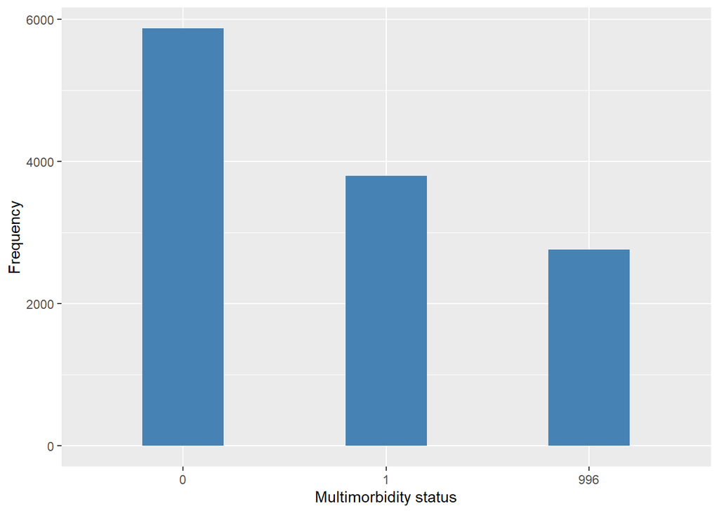

#### 2.1.7.4 Validation

## 2.2 Summary of descriptive statistics of the harmonised variable accross populations and waves

Two tables are generated:

1. Percentages of categories in each harmonised variable.
2. Frequencies and percentages of individuals with different trajectories. To avoid too large table, Only trajectories with percentages larger than 0.3 are shown.

Multimorbidity status

| val | label | W1 | W2 | W3 | W4 | W5 | W6 | W7 |
| --- | --- | --- | --- | --- | --- | --- | --- | --- |
| 0 | No | 68.88 | 60.82 | 58.58 | 56.56 | 50.27 | 49.13 | 47.24 |
| 1 | Yes | 31.06 | 33.3 | 31.24 | 30.17 | 31.43 | 30.19 | 30.55 |
| 991 | CAPI interviewer error | 0 | 0 | 0 | 0 | 0 | 0 | 0 |
| 992 | Impute | 0 | 0 | 0 | 0 | 0 | 0 | 0 |
| 993 | Disable to measure | 0 | 0 | 0 | 0 | 0 | 0 | 0 |
| 994 | Not attempt not done | 0 | 0 | 0 | 0 | 0 | 0 | 0 |
| 995 | Does not answer | 0 | 0 | 0 | 0 | 0 | 0 | 0 |
| 996 | Not applicable | 0 | 5.87 | 10.19 | 13.2 | 18.26 | 20.65 | 22.22 |
| 997 | Refuse | 0 | 0 | 0 | 0 | 0 | 0 | 0 |
| 998 | Do not know | 0 | 0 | 0 | 0 | 0 | 0 | 0 |
| 999 | Missing | 0.06 | 0.01 | 0 | 0.06 | 0.05 | 0.04 | 0 |
| NA | NA | 0 | 0 | 0 | 0 | 0 | 0 | 0 |
| n | sample size | 12099 | 10020 | 10878 | 12731 | 12569 | 13359 | 12427 |

|  | val | frq | raw.prc |
| --- | --- | --- | --- |
| 1 | 0000000 | 2119 | 11.46 |
| 2 | 0000001 | 147 | 0.80 |
| 3 | 000000NA | 265 | 1.43 |
| 5 | 0000011 | 157 | 0.85 |
| 9 | 00000NANA | 172 | 0.93 |
| 14 | 0000111 | 165 | 0.89 |
| 26 | 0000NANANA | 267 | 1.44 |
| 34 | 0001111 | 200 | 1.08 |
| 43 | 000NA000 | 59 | 0.32 |
| 62 | 000NANANANA | 466 | 2.52 |
| 73 | 0011111 | 181 | 0.98 |
| 89 | 00NA0000 | 56 | 0.30 |
| 125 | 00NANANANANA | 752 | 4.07 |
| 142 | 0111111 | 274 | 1.48 |
| 157 | 011NANANANA | 59 | 0.32 |
| 167 | 01NANANANANA | 102 | 0.55 |
| 196 | 0NA0NANANANA | 70 | 0.38 |
| 246 | 0NANANANANANA | 1321 | 7.14 |
| 286 | 1111111 | 1012 | 5.47 |
| 287 | 111111NA | 224 | 1.21 |
| 289 | 11111NANA | 194 | 1.05 |
| 293 | 1111NANANA | 217 | 1.17 |
| 300 | 111NANANANA | 328 | 1.77 |
| 316 | 11NANANANANA | 406 | 2.20 |
| 354 | 1NANANANANANA | 758 | 4.10 |
| 389 | NANA00000 | 600 | 3.25 |
| 391 | NANA0000NA | 81 | 0.44 |
| 397 | NANA000NANA | 63 | 0.34 |
| 409 | NANA00NANANA | 107 | 0.58 |
| 438 | NANA0NANANANA | 255 | 1.38 |
| 443 | NANA11111 | 108 | 0.58 |
| 459 | NANANA0000 | 1129 | 6.11 |
| 460 | NANANA0001 | 91 | 0.49 |
| 461 | NANANA000NA | 149 | 0.81 |
| 463 | NANANA0011 | 70 | 0.38 |
| 467 | NANANA00NANA | 120 | 0.65 |
| 471 | NANANA0111 | 102 | 0.55 |
| 483 | NANANA0NANANA | 271 | 1.47 |
| 489 | NANANA1111 | 293 | 1.58 |
| 490 | NANANA111NA | 69 | 0.37 |
| 497 | NANANA1NANANA | 91 | 0.49 |
| 508 | NANANANANA00 | 772 | 4.18 |
| 510 | NANANANANA0NA | 223 | 1.21 |
| 512 | NANANANANA11 | 144 | 0.78 |
| 514 | NANANANANANA0 | 442 | 2.39 |
| 515 | NANANANANANA1 | 68 | 0.37 |

# 3 Quality estimation